# Final

## Introduction

The data sets used in this project are from Google’s COVID-19 Community Mobility Reports database (https://www.google.com/covid19/mobility/). This source includes data sets with identical variables about the mobility of populations from many countries and sub regions. The data is collected by Google for public health utility via their products such as Google Maps. In brevity, the data describes how the mobility of a diverse range of communities has changed in specific activities throughout the global Covid-19 pandemic (2020-2021). I obtained this data after doing research into databases and data sets related to the Covid-19 pandemic in my own local community. From this data, I hope to get a better understanding and obtain insight about how my local community, Alameda County, CA USA, has altered due to new public regulations and awareness of the Covid-19 pandemic. Furthermore, I am interested in the differences of mobility between South Korea and the US. Hopefully, I will be able to better visualize how South Korea maintains a much stronger public health response than the US.

I have two primary questions:

1. How does the US and South Korea compare in community mobility this past year?
2. How does my local community, Alameda County, CA US, compare to the rest of California is community mobility this past year?

## Loading Data and Initial Observation of Data:

```r
library(tidyverse)
library(gt)
library(lubridate)
```

```r
library(ggplot2)
library(reshape2)
library(rmarkdown)

#Loading in the data
korea_mobility <- read.csv("/Users/mileslee/Desktop/DDD-I21/Region_Mobility_Report_CSVs/2020_KR_Region_Mobility_Report.csv")
united_states_mobility <- read.csv("/Users/mileslee/Desktop/DDD-I21/Region_Mobility_Report_CSVs/2020_US_Region_Mobility_Report.csv")
#Make a copy of the data so you don't override the original.
kr <- korea_mobility
us <- united_states_mobility
#taking a peak at at the individual mobility data sets.
colnames(kr)
kr[1:3,]
nrow(kr)
colnames(us)
us[1:3,]
nrow(us)
```

[output not shown]

First, I load all the appropriate libraries and the United States and Korea regional csv files from my local drive. Then, make a copy of the original data into data frames (us, kr) I will mutate. Lastly, I take a brief look at the column names and amount of rows for both the United States and Korean data.

## Date Processing:

```r
#Check to see if the date data is in the date format. If not, convert to date format.
class(us$date[1])
```

```
## [1] "character"
```

```r
class(kr$date[1])
```

```
## [1] "character"
```

```r
us$formatted_date <- as.Date(us$date, format = "%Y-%m-%d")
class(us$formatted_date[1])
```

```
## [1] "Date"
```

```r
kr$formatted_date <- as.Date(kr$date, format = "%Y-%m-%d")
class(kr$formatted_date[1])
```

```
## [1] "Date"
```

Before I begin to alter or create new data frames, I check to see if the dates in the United States (us) and Korea (kr) data frames is in the R format. Since, they were just character strings, I use the as.Date function to make a new column with the dates formatted called “formatted_date.”

## Prep for Merging:

```r
#Make sub-dataframes (by rows and cols) and merge dataframes in order to capture the data used to answer the questions above.
vars_interest <- c("formatted_date", "country_region", "sub_region_1","sub_region_2", "retail_and_recreation_percent_change_from_baseline",
                   "grocery_and_pharmacy_percent_change_from_baseline", "parks_percent_change_from_baseline",
                   "transit_stations_percent_change_from_baseline", "workplaces_percent_change_from_baseline",
                   "residential_percent_change_from_baseline")
#Data from only specific columns and rows about mobility of US as a country.
us_country_df <- us[vars_interest] %>% filter(us$sub_region_1 == "")
#Data from only specific columns and rows about mobility of California. This excludes data about each county in California.
ca_state_df <- us[vars_interest] %>% filter(us$iso_3166_2_code == "US-CA")
#Data from only specific columns and rows about mobility of Korea as a country.
kr_country_df <- kr[vars_interest] %>% filter(kr$metro_area == "")
#Data from only specific columns and rows about mobility of Alameda county.
al_county_df <- us[vars_interest] %>% filter(us$census_fips_code == 6001)
```

Since the United States (us) and Korean (kr) data frames currently contain data that I do not want to work with, I create new data frames (us_country_df, ca_state_df, kr_country_df, al_county_df) that only include specific columns specified by “vars_interest” and certain rows relating to the United States (as a country), Korea (as a country), California, and Alameda county.

## Merges:

```r
#Merge the two counties' data into one data frame. Chose to merge data with dates that are only included in both data sets. This way comparison is more simple.
us_kr_df <- merge(us_country_df,kr_country_df, by = "formatted_date", suffixes = c("_us", "_kr"))
al_ca_df <- merge(al_county_df, ca_state_df, by = "formatted_date", suffixes = c("_al", "_ca"))
#checking success of merge and any unwanted results of the merge.
ncol(us_kr_df) == 2*length(vars_interest) - 1
```

```
## [1] TRUE
```

```r
ncol(al_ca_df) == 2*length(vars_interest) - 1
```

```
## [1] TRUE
```

```r
nrow(us_kr_df) == nrow(subset(us, sub_region_1 == ""))
```

```
## [1] TRUE
```

```r
nrow(al_ca_df) == nrow(subset(us, sub_region_1 == ""))
```

```
## [1] TRUE
```

```r
#All TRUE results demonstrate that the merged data frames have the correct amount of variables and rows.
```

## Missing Data:

```r
#Missing Data: Identifying, flagging, and handling missing data.
missing_check_us_df <- sapply(us, function(x) sum(is.na(x)))
missing_check_us_df
```

```
##                                country_region_code
##                                                  0
##                                     country_region
##                                                  0
##                                       sub_region_1
##                                                  0
##                                       sub_region_2
##                                                  0
##                                         metro_area
##                                             819195
##                                    iso_3166_2_code
##                                                  0
##                                   census_fips_code
##                                              16524
##                                               date
##                                                  0
## retail_and_recreation_percent_change_from_baseline
##                                             273224
##  grocery_and_pharmacy_percent_change_from_baseline
##                                             323720
##                 parks_percent_change_from_baseline
##                                             622511
##      transit_stations_percent_change_from_baseline
##                                             506810
##            workplaces_percent_change_from_baseline
##                                              24546
##           residential_percent_change_from_baseline
##                                             381946
##                                     formatted_date
##                                                  0
```

```r
missing_check_kr_df <- sapply(kr, function(x) sum(is.na(x)))
missing_check_kr_df
```

```
##                                country_region_code
##                                                  0
##                                     country_region
##                                                  0
##                                       sub_region_1
##                                                648
##                                       sub_region_2
##                                                648
##                                         metro_area
##                                                  0
##                                    iso_3166_2_code
##                                                648
##                                   census_fips_code
##                                                648
##                                               date
##                                                  0
## retail_and_recreation_percent_change_from_baseline
##                                                  0
##  grocery_and_pharmacy_percent_change_from_baseline
##                                                  0
##                 parks_percent_change_from_baseline
##                                                  0
##      transit_stations_percent_change_from_baseline
##                                                  0
##            workplaces_percent_change_from_baseline
##                                                  0
##           residential_percent_change_from_baseline
##                                                  0
##                                     formatted_date
##                                                  0
```

```r
missing_check_us_kr_df <- sapply(us_kr_df, function(x) sum(is.na(x)))
missing_check_us_kr_df
```

```
##                                        formatted_date
##                                                     0
##                                     country_region_us
##                                                     0
##                                       sub_region_1_us
##                                                     0
##                                       sub_region_2_us
##                                                     0
## retail_and_recreation_percent_change_from_baseline_us
##                                                     0
##  grocery_and_pharmacy_percent_change_from_baseline_us
##                                                     0
##                 parks_percent_change_from_baseline_us
##                                                     0
##      transit_stations_percent_change_from_baseline_us
##                                                     0
##            workplaces_percent_change_from_baseline_us
##                                                     0
##           residential_percent_change_from_baseline_us
##                                                     0
##                                     country_region_kr
##                                                     0
##                                       sub_region_1_kr
##                                                   324
##                                       sub_region_2_kr
##                                                   324
## retail_and_recreation_percent_change_from_baseline_kr
##                                                     0
##  grocery_and_pharmacy_percent_change_from_baseline_kr
##                                                     0
##                 parks_percent_change_from_baseline_kr
##                                                     0
##      transit_stations_percent_change_from_baseline_kr
##                                                     0
##            workplaces_percent_change_from_baseline_kr
##                                                     0
##           residential_percent_change_from_baseline_kr
##                                                     0
```

```r
missing_check_la_ca_df <- sapply(al_ca_df, function(x) sum(is.na(x)))
missing_check_la_ca_df
```

```
##                                        formatted_date
##                                                     0
##                                     country_region_al
##                                                     0
##                                       sub_region_1_al
##                                                     0
##                                       sub_region_2_al
##                                                     0
## retail_and_recreation_percent_change_from_baseline_al
##                                                     0
##  grocery_and_pharmacy_percent_change_from_baseline_al
##                                                     0
##                 parks_percent_change_from_baseline_al
##                                                     0
##      transit_stations_percent_change_from_baseline_al
##                                                     0
##            workplaces_percent_change_from_baseline_al
##                                                     0
##           residential_percent_change_from_baseline_al
##                                                     0
##                                     country_region_ca
##                                                     0
##                                       sub_region_1_ca
##                                                     0
##                                       sub_region_2_ca
##                                                     0
## retail_and_recreation_percent_change_from_baseline_ca
##                                                     0
##  grocery_and_pharmacy_percent_change_from_baseline_ca
##                                                     0
##                 parks_percent_change_from_baseline_ca
##                                                     0
##      transit_stations_percent_change_from_baseline_ca
##                                                     0
##            workplaces_percent_change_from_baseline_ca
##                                                     0
##           residential_percent_change_from_baseline_ca
##                                                     0
```

The code above identifies if there are any missing data in the data frames and prints the amount of NA values in each column. The complete us mobility data set (us) has many missing values. These values cannot reasonably be extrapolated nor can they be assumed to be zero since the missing mobility value is likely not because there isn’t any mobility but because there was no mobility measured by Google. Despite the many missing values identified, I have only chosen to look at data from California and Alameda county, CA, and there are fortunately no missing values. Likewise, the korean mobility data set (kr) doesn’t have any missing values for the non-metro areas. If subsets that have NA values were to be used, the programmer would have to ignore those values and report how the missing data affects the results. Since I will not be working with data which includes missing values,there is no need to create binary flags highlighting where there are missing values. Furthermore, a previous removal of columns that aren’t significant to the project questions eliminates the need to take care of most missing values in the data frames.

## New Variables and New Data Frames:

```r
#Variable Creation and Coding:

#Creating a row ID
us_kr_df$id <- 1:nrow(us_kr_df)
al_ca_df$id <- 1:nrow(al_ca_df)

#Binary flag for negative change: 1 means neg change, 0 means no or positive change
us_kr_df <- us_kr_df %>%
            mutate(retail_and_recreation_us_neg_change = ifelse(retail_and_recreation_percent_change_from_baseline_us < 0, 1, 0),
                    grocery_and_pharmacy_us_neg_change = ifelse(grocery_and_pharmacy_percent_change_from_baseline_us < 0, 1, 0),
                    parks_us_neg_change = ifelse(parks_percent_change_from_baseline_us < 0, 1, 0),
                    transit_stations_us_neg_change = ifelse(transit_stations_percent_change_from_baseline_us < 0, 1, 0),
                    workplaces_us_neg_change = ifelse(workplaces_percent_change_from_baseline_us < 0, 1, 0),
                    residential_us_neg_change = ifelse(residential_percent_change_from_baseline_us < 0, 1, 0),
                    retail_and_recreation_kr_neg_change = ifelse(retail_and_recreation_percent_change_from_baseline_kr < 0, 1, 0),
                    grocery_and_pharmacy_kr_neg_change = ifelse(grocery_and_pharmacy_percent_change_from_baseline_kr < 0, 1, 0),
                    parks_kr_neg_change = ifelse(parks_percent_change_from_baseline_kr < 0, 1, 0),
                    transit_stations_kr_neg_change = ifelse(transit_stations_percent_change_from_baseline_kr < 0, 1, 0),
                    workplaces_kr_neg_change = ifelse(workplaces_percent_change_from_baseline_kr < 0, 1, 0),
                    residential_kr_neg_change = ifelse(residential_percent_change_from_baseline_kr < 0, 1, 0))
```

New Variables in the United States and Korean data frame:

- id = a unique row number for each row.
- For each mobility data column, a new column containing a binary flag is produced. If the percent change is negative for the specific day, the flag has a value of 1. If the percent change is zero or positive for the specific day, the flag has a value of 0.

New Variables in the California and Alameda county data frame:

- id = a unique row number for each row.

```r
#Dataframe with negative change count per type of mobility and average change.
us_kr_neg_pos_df <- data.frame("mobility_type" = c("retail_and_recreation", "grocery_and_pharmacy", "parks", "transit_stations", "workplaces", "residential"))
us_kr_neg_pos_df$percent_of_negative_days_us <- round(100 * colSums(us_kr_df %>% select(retail_and_recreation_us_neg_change,
                                                                                        grocery_and_pharmacy_us_neg_change,
                                                                                        parks_us_neg_change,
                                                                                        transit_stations_us_neg_change,
                                                                                        workplaces_us_neg_change,
                                                                                        residential_us_neg_change)) / nrow(us_kr_df))
us_kr_neg_pos_df$percent_of_negative_days_kr <- round(100 * colSums(us_kr_df %>% select(retail_and_recreation_kr_neg_change,
                                                                                        grocery_and_pharmacy_kr_neg_change,
                                                                                        parks_kr_neg_change,
                                                                                        transit_stations_kr_neg_change,
                                                                                        workplaces_kr_neg_change,
                                                                                        residential_kr_neg_change)) / nrow(us_kr_df))
us_kr_neg_pos_df$percent_of_positive_days_us <- 100 - us_kr_neg_pos_df$percent_of_negative_days_us
us_kr_neg_pos_df$percent_of_positive_days_kr <- 100 - us_kr_neg_pos_df$percent_of_negative_days_kr
```

A data frame (us_kr_neg_pos_df) is produced that contains the total sum of negative change and positive/zero change days per type of mobility for both countries. This data frame will be used later to create a table to visualize the summary data.

```r
#averages of each variable per month and total change per month for US and Korean data
us_kr_avg_percent_change_per_month_df <- us_kr_df %>%
  group_by(year(us_kr_df$formatted_date),month(us_kr_df$formatted_date)) %>%
  summarise(retail_and_recreation_us = round(mean(retail_and_recreation_percent_change_from_baseline_us)),
            retail_and_recreation_kr = round(mean(retail_and_recreation_percent_change_from_baseline_kr)),
            grocery_and_pharmacy_us = round(mean(grocery_and_pharmacy_percent_change_from_baseline_us)),
            grocery_and_pharmacy_kr = round(mean(grocery_and_pharmacy_percent_change_from_baseline_kr)),
            parks_us = round(mean(parks_percent_change_from_baseline_us)),
            parks_kr = round(mean(parks_percent_change_from_baseline_kr)),
            transit_station_us = round(mean(transit_stations_percent_change_from_baseline_us)),
            transit_station_kr = round(mean(transit_stations_percent_change_from_baseline_kr)),
            workplaces_us = round(mean(workplaces_percent_change_from_baseline_us)),
            workplaces_kr = round(mean(workplaces_percent_change_from_baseline_kr)),
            residential_us = round(mean(residential_percent_change_from_baseline_us)),
            residential_kr = round(mean(residential_percent_change_from_baseline_kr)),
            all_us = round((retail_and_recreation_us + grocery_and_pharmacy_us + parks_us + transit_station_us + workplaces_us + residential_us)/6),
            all_kr = round((retail_and_recreation_kr + grocery_and_pharmacy_kr + parks_kr + transit_station_kr + workplaces_kr + residential_kr)/6))
us_kr_avg_percent_change_per_month_df$change_us <- ""
levels(us_kr_avg_percent_change_per_month_df$change_us) <- c(levels(us_kr_avg_percent_change_per_month_df$change_us), "High")
levels(us_kr_avg_percent_change_per_month_df$change_us) <- c(levels(us_kr_avg_percent_change_per_month_df$change_us), "Low")
us_kr_avg_percent_change_per_month_df$change_us <- ifelse(abs(us_kr_avg_percent_change_per_month_df$all_us) > 15, "High", "Low")
us_kr_avg_percent_change_per_month_df$change_kr <- ""
levels(us_kr_avg_percent_change_per_month_df$change_kr) <- c(levels(us_kr_avg_percent_change_per_month_df$change_kr), "High")
levels(us_kr_avg_percent_change_per_month_df$change_kr) <- c(levels(us_kr_avg_percent_change_per_month_df$change_kr), "Low")
us_kr_avg_percent_change_per_month_df$change_kr <- ifelse(abs(us_kr_avg_percent_change_per_month_df$all_kr) > 15, "High", "Low")

#averages of each variable per month and total change per month for California and Alameda county data.
al_ca_avg_percent_change_per_month_df <- al_ca_df %>%
  group_by(year(al_ca_df$formatted_date),month(al_ca_df$formatted_date)) %>%
  summarise(retail_and_recreation_al = round(mean(retail_and_recreation_percent_change_from_baseline_al)),
            retail_and_recreation_ca = round(mean(retail_and_recreation_percent_change_from_baseline_ca)),
            grocery_and_pharmacy_al = round(mean(grocery_and_pharmacy_percent_change_from_baseline_al)),
            grocery_and_pharmacy_ca = round(mean(grocery_and_pharmacy_percent_change_from_baseline_ca)),
            parks_al = round(mean(parks_percent_change_from_baseline_al)),
            parks_ca = round(mean(parks_percent_change_from_baseline_ca)),
            transit_station_al = round(mean(transit_stations_percent_change_from_baseline_al)),
            transit_station_ca = round(mean(transit_stations_percent_change_from_baseline_ca)),
            workplaces_al = round(mean(workplaces_percent_change_from_baseline_al)),
            workplaces_ca = round(mean(workplaces_percent_change_from_baseline_ca)),
            residential_al = round(mean(residential_percent_change_from_baseline_al)),
            residential_ca = round(mean(residential_percent_change_from_baseline_ca)),
            all_al = round((retail_and_recreation_al + grocery_and_pharmacy_al + parks_al + transit_station_al + workplaces_al + residential_al)/6),
            all_ca = round((retail_and_recreation_ca + grocery_and_pharmacy_ca + parks_ca + transit_station_ca + workplaces_ca+ residential_ca)/6))
al_ca_avg_percent_change_per_month_df$change_al <- ""
levels(al_ca_avg_percent_change_per_month_df$change_al) <- c(levels(al_ca_avg_percent_change_per_month_df$change_al), "High")
levels(al_ca_avg_percent_change_per_month_df$change_al) <- c(levels(al_ca_avg_percent_change_per_month_df$change_al), "Low")
al_ca_avg_percent_change_per_month_df$change_al <- ifelse(abs(al_ca_avg_percent_change_per_month_df$all_al) > 15, "High", "Low")
al_ca_avg_percent_change_per_month_df$change_ca <- ""
levels(al_ca_avg_percent_change_per_month_df$change_ca) <- c(levels(al_ca_avg_percent_change_per_month_df$change_ca), "High")
levels(al_ca_avg_percent_change_per_month_df$change_ca) <- c(levels(al_ca_avg_percent_change_per_month_df$change_ca), "Low")
al_ca_avg_percent_change_per_month_df$change_ca <- ifelse(abs(al_ca_avg_percent_change_per_month_df$all_ca) > 15, "High", "Low")
```

The purpose of the code above is to summarize the raw data into average mobility percent change by month. This way, it will be easier to visualize the differences between two geographical locations in terms of their populations mobility activity.

For both the United states and Korean data frame (us_kr_df) and the California and Alameda county data frame (al_ca_df), a new data frame (us_kr_avg_percent_change_per_month_df and al_ca_avg_percent_change_per_month_df) is produced with the following variables/columns:

*For each type of mobility for each geographical location, there is a column that contains the rounded average percent change per month.

*For each geographical location, there is a column that is a factor variable with two values: High and Low. The value is set to High if the total average percent change of all mobility for the specific geographical location is above an arbitrary value of 15%. In the future, the threshold value can be updated to better classify the data.

These new data frames will be used below in a table for visualization of the summary data.

# Table 1

```r
#Table 1: us_kr_neg_pos_df (US vs KR)
us_kr_neg_pos_df %>%
  gt(rowname_col = "mobility_type") %>%
  tab_header(title = "Table 1: Percent of Days (in 12 months) of Positive and Negative Change in Mobility") %>%
  cols_label(percent_of_negative_days_us = "Negative in US",
             percent_of_negative_days_kr = "Negative in Korea",
             percent_of_positive_days_us = "Positive in US",
             percent_of_positive_days_kr = "Positive in Korea")
```

Table 1: Percent of Days (in 12 months) of Positive and Negative Change in Mobility

|  | Negative in US | Negative in Korea | Positive in US | Positive in Korea |
| --- | --- | --- | --- | --- |
| retail_and_recreation | 91 | 94 | 9 | 6 |
| grocery_and_pharmacy | 78 | 21 | 22 | 79 |
| parks | 31 | 17 | 69 | 83 |
| transit_stations | 93 | 85 | 7 | 15 |
| workplaces | 93 | 80 | 7 | 20 |
| residential | 5 | 4 | 95 | 96 |

This first table represents the data in the us_kr_neg_pos_df data frame. Here, the total number of negative and positive change days per type of mobility is compared between the United States and Korea.

Table 1 shows at a very high and abstracted level that the difference between the United States and Korea in terms of mobility accross a diverse range of activities is similar. However, the United states seems to have more days with negative change in mobility than Korea. And, unlike the United States which saw a majority of days with negative change in mobility for grocery shopping, Korea saw a majority of days with positive change.

# Table 2

```r
#Table 2: us_kr_avg_percent_change_per_month_df (US vs KR)
us_kr_avg_percent_change_per_month_df$date_names <- c("Feb", "Mar", "Apr", "May", "Jun", "Jul", "Aug", "Sep",
                                                       "Oct", "Nov", "Dec", "Jan")
us_kr_avg_percent_change_per_month_df %>%
  group_by(`year(us_kr_df$formatted_date)`, date_names) %>%
  select(all_us, all_kr, change_us, change_kr) %>%
  gt() %>%
  tab_header(title = "Table 2: Average Percent Change from Baseline of Each Type of Mobility Per Month in US and Korea") %>%
  cols_label(all_us = "US-All",
             all_kr = "Korean-All",
             change_us = "US Overall Change (Qualitative)",
             change_kr = "Korean Overall Change (Qualitative)")
```

Table 2: Average Percent Change from Baseline of Each Type of Mobility Per Month in US and Korea

| US-All | Korean-All | US Overall Change (Qualitative) | Korean Overall Change (Qualitative) |
| --- | --- | --- | --- |
| 2020 - Feb |  |  |  |
| 4 | -9 | Low | Low |
| 2020 - Mar |  |  |  |
| -7 | -5 | Low | Low |
| 2020 - Apr |  |  |  |
| -24 | 2 | High | Low |
| 2020 - May |  |  |  |
| -12 | 7 | Low | Low |
| 2020 - Jun |  |  |  |
| -2 | 6 | Low | Low |
| 2020 - Jul |  |  |  |
| -2 | 4 | Low | Low |
| 2020 - Aug |  |  |  |
| -3 | 0 | Low | Low |
| 2020 - Sep |  |  |  |
| -6 | 1 | Low | Low |
| 2020 - Oct |  |  |  |
| -9 | 8 | Low | Low |
| 2020 - Nov |  |  |  |
| -14 | 1 | Low | Low |
| 2020 - Dec |  |  |  |
| -17 | -7 | High | Low |
| 2021 - Jan |  |  |  |
| -24 | -18 | High | High |

The second graph represents the data in the us_kr_avg_percent_change_per_month_df data frame. The rows are the month and year and the columns are a quantitative and qualitative representation of the total average percent change in mobility in each country.

Table 2 shows that for the United States, the majority of months in the past year have had a negative change in mobility of people. On the other hand, the table shows that for Korea, the majority of months has a small and positive change in mobility of people.

# Table 3

```r
#Table 3: us_kr_avg_percent_change_per_month_df (Al vs CA)
al_ca_avg_percent_change_per_month_df$date_names <- c("Feb", "Mar", "Apr", "May", "Jun", "Jul", "Aug", "Sep",
                                                      "Oct", "Nov", "Dec", "Jan")
al_ca_avg_percent_change_per_month_df %>%
  group_by(`year(al_ca_df$formatted_date)`, date_names) %>%
  select(all_al, all_ca, change_al, change_ca) %>%
  gt() %>%
  tab_header(title = "Table 3: Average Percent Change from Baseline of Each Type of Mobility Per Mon h in Alameda County, CA and California") %>%
  cols_label(all_al = "Alameda County-All",
             all_ca = "California-All",
             change_al = "Alameda County Overall Change (Qualitative)",
             change_ca = "California Overall Change (Qualitative)")
```

Table 3: Average Percent Change from Baseline of Each Type of Mobility Per Mon h in Alameda County, CA and California

| Alameda County-All | California-All | Alameda County Overall Change (Qualitative) | California Overall Change (Qualitative) |
| --- | --- | --- | --- |
| 2020 - Feb |  |  |  |
| 4 | 3 | Low | Low |
| 2020 - Mar |  |  |  |
| -15 | -13 | Low | Low |
| 2020 - Apr |  |  |  |
| -32 | -31 | High | High |
| 2020 - May |  |  |  |
| -24 | -22 | High | High |
| 2020 - Jun |  |  |  |
| -19 | -16 | High | High |
| 2020 - Jul |  |  |  |
| -18 | -15 | High | Low |
| 2020 - Aug |  |  |  |
| -21 | -16 | High | High |
| 2020 - Sep |  |  |  |
| -23 | -18 | High | High |
| 2020 - Oct |  |  |  |
| -22 | -18 | High | High |
| 2020 - Nov |  |  |  |
| -24 | -21 | High | High |
| 2020 - Dec |  |  |  |
| -27 | -24 | High | High |
| 2021 - Jan |  |  |  |
| -34 | -28 | High | High |

The third graph represents data in the al_ca_avg_percent_change_per_month_df data frames. The rows are the month and year and the columns are a quantitative and qualitative representation of the total average percent change in mobility in each location.

# US and Korea Graphs

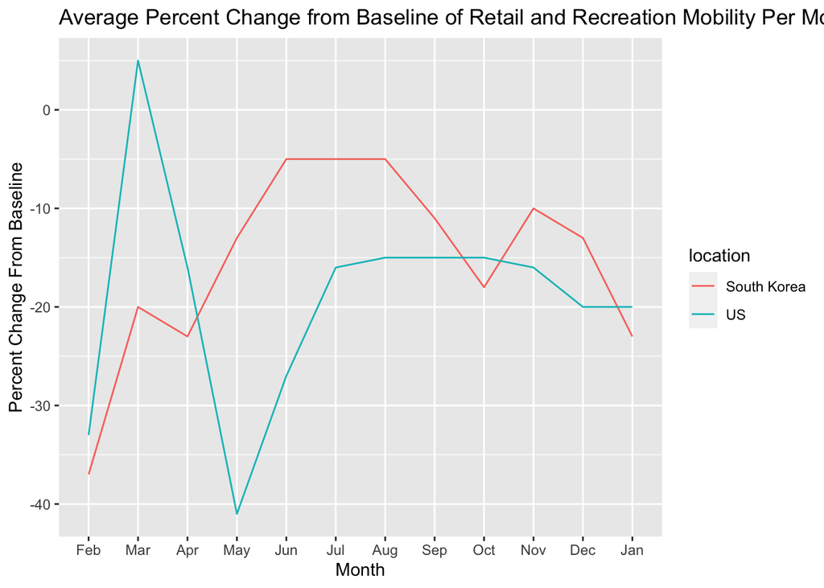

```r
#Graph 1:
us_kr_avg_percent_change_per_month_df$date_numbers <- c(2,3,4,5,6,7,8,9,10,11,12,1)
temp_df <- melt(us_kr_avg_percent_change_per_month_df, id.vars = 'date_numbers', variable.name = 'series') %>%
  filter(series != "year(us_kr_df$formatted_date)") %>%
  filter(series != "month(us_kr_df$formatted_date)") %>%
  filter(series != "change_us") %>%
  filter(series != "change_kr") %>%
  filter(series != "date_names")
temp_df$series <- as.character(temp_df$series)
temp_df$value <- as.integer(temp_df$value)
temp_df$location <- ifelse(grepl("_us", temp_df$series), "US", "South Korea")
ggplot(data = temp_df  %>% filter(series == "retail_and_recreation_us" | series == "retail_and_recreation_kr"), aes(x = date_numbers, y = value, color = location)) +
  geom_line() +
  xlab("Month") +
  ylab("Percent Change From Baseline") +
  ggtitle("Average Percent Change from Baseline of Retail and Recreation Mobility Per Month in US and Korea, 2020-2021") +
  scale_x_discrete(name = "Month",
                   limits = c("Feb", "Mar", "Apr", "May", "Jun", "Jul", "Aug", "Sep",
                              "Oct", "Nov", "Dec", "Jan"))
```

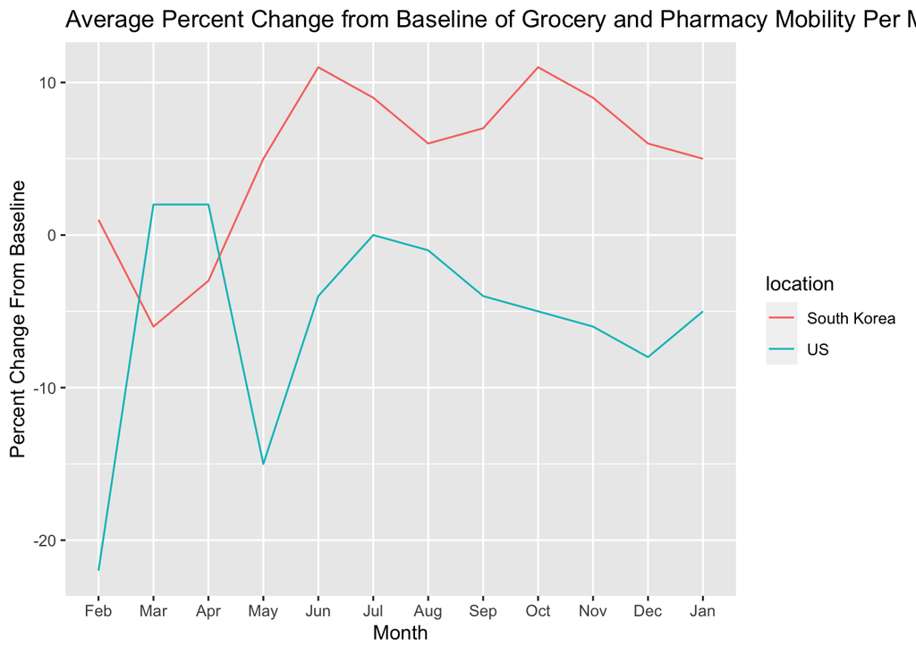

```r
ggplot(data = temp_df  %>% filter(series == "grocery_and_pharmacy_us" | series == "grocery_and_pharmacy_kr"), aes(x = date_numbers, y = value, color = location)) +
  geom_line() +
  xlab("Month") +
  ylab("Percent Change From Baseline") +
  ggtitle("Average Percent Change from Baseline of Grocery and Pharmacy Mobility Per Month in US and Korea, 2020-2021") +
  scale_x_discrete(name = "Month",
                   limits = c("Feb", "Mar", "Apr", "May", "Jun", "Jul", "Aug", "Sep",
                              "Oct", "Nov", "Dec", "Jan"))
```

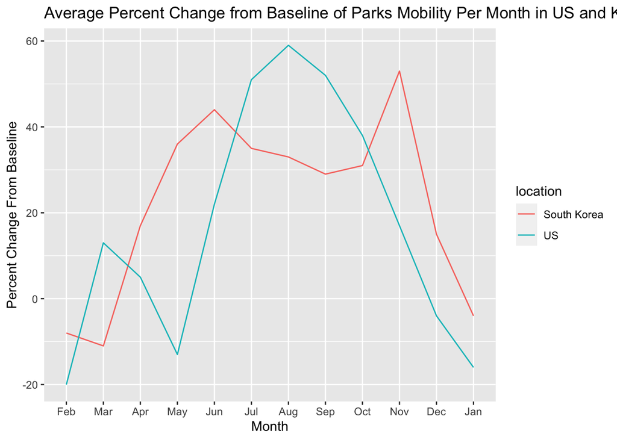

```r
ggplot(data = temp_df  %>% filter(series == "parks_us" | series == "parks_kr"), aes(x = date_numbers, y = value, color = location)) +
  geom_line() +
  xlab("Month") +
  ylab("Percent Change From Baseline") +
  ggtitle("Average Percent Change from Baseline of Parks Mobility Per Month in US and Korea, 2020-2021") +
  scale_x_discrete(name = "Month",
                   limits = c("Feb", "Mar", "Apr", "May", "Jun", "Jul", "Aug", "Sep",
                              "Oct", "Nov", "Dec", "Jan"))
```

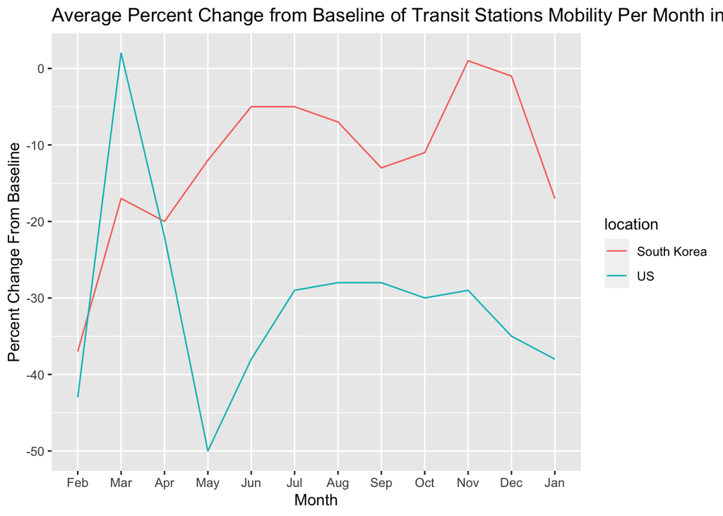

```r
ggplot(data = temp_df  %>% filter(series == "transit_station_us" | series == "transit_station_kr"), aes(x = date_numbers, y = value, color = location)) +
  geom_line() +
  xlab("Month") +
  ylab("Percent Change From Baseline") +
  ggtitle("Average Percent Change from Baseline of Transit Stations Mobility Per Month in US and Korea, 2020-2021") +
  scale_x_discrete(name = "Month",
                   limits = c("Feb", "Mar", "Apr", "May", "Jun", "Jul", "Aug", "Sep",
                              "Oct", "Nov", "Dec", "Jan"))
```

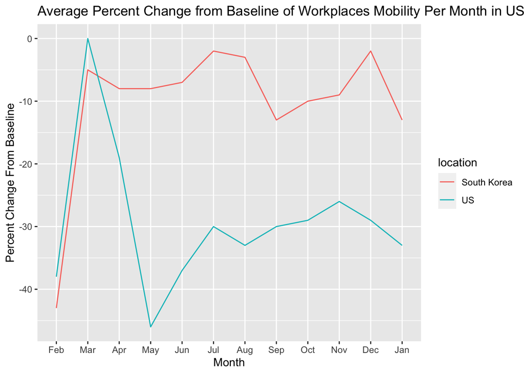

```r
ggplot(data = temp_df  %>% filter(series == "workplaces_us" | series == "workplaces_kr"), aes(x = date_numbers, y = value, color = location)) +
  geom_line() +
  xlab("Month") +
  ylab("Percent Change From Baseline") +
  ggtitle("Average Percent Change from Baseline of Workplaces Mobility Per Month in US and Korea, 2020-2021") +
  scale_x_discrete(name = "Month",
                   limits = c("Feb", "Mar", "Apr", "May", "Jun", "Jul", "Aug", "Sep",
                              "Oct", "Nov", "Dec", "Jan"))
```

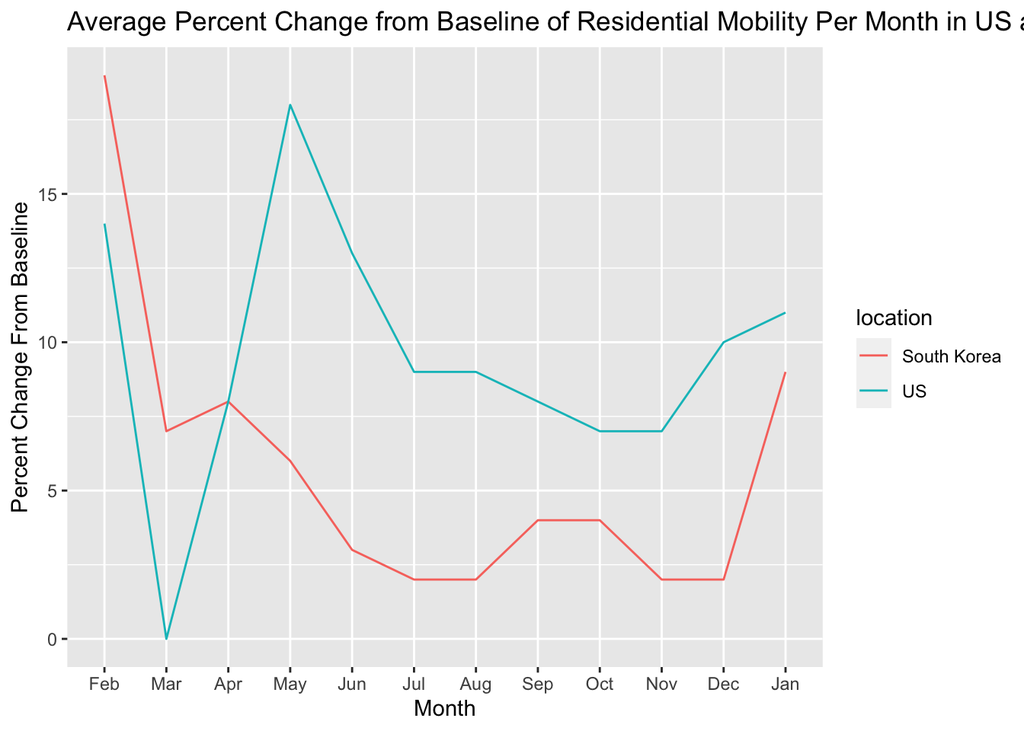

```r
ggplot(data = temp_df  %>% filter(series == "residential_us" | series == "residential_kr"), aes(x = date_numbers, y = value, color = location)) +
  geom_line() +
  xlab("Month") +
  ylab("Percent Change From Baseline") +
  ggtitle("Average Percent Change from Baseline of Residential Mobility Per Month in US and Korea, 2020-2021") +
  scale_x_discrete(name = "Month",
                   limits = c("Feb", "Mar", "Apr", "May", "Jun", "Jul", "Aug", "Sep",
                              "Oct", "Nov", "Dec", "Jan"))
```

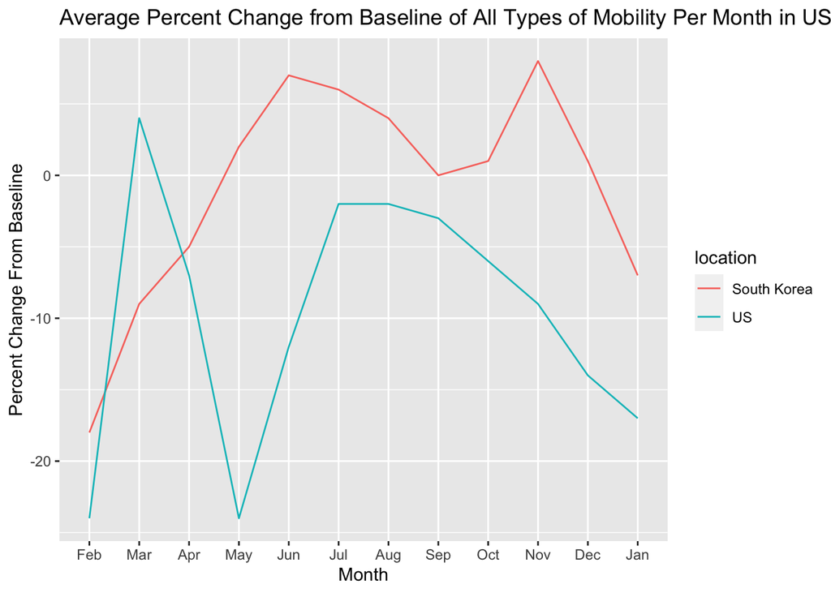

```r
ggplot(data = temp_df  %>% filter(series == "all_us" | series == "all_kr"), aes(x = date_numbers, y = value, color = location)) +
  geom_line() +
  xlab("Month") +
  ylab("Percent Change From Baseline") +
  ggtitle("Average Percent Change from Baseline of All Types of Mobility Per Month in US and Korea, 2020-2021") +
  scale_x_discrete(name = "Month",
                   limits = c("Feb", "Mar", "Apr", "May", "Jun", "Jul", "Aug", "Sep",
                              "Oct", "Nov", "Dec", "Jan"))
```

```r
#for conclusion section only.
temp_df_ <- temp_df
```

These graphs compare the average percent change in mobility per month for both countries in terms of a range of types of mobility. In order to use the data in the us_kr_avg_percent_change_per_month_df data frame, I needed to create some new columns:

- A column with the month number
- A column with the location

I also needed to convert the number data from characters to integer values.

Furthermore and most critically, the data frame needed to be transformed so the columns that are plotted as the dependent variables are held in a single column called “series”. Without this transformation, the multiple columns of the data wouldn’t be able to be graphed adjacently on the same plot.

As a result of the plots above, there are a few patterns that emerge:

- Residential activity was mostly positive across all months. Furthermore, Korea had less positive change in mobility than the United States observed.
- Activity that required social interaction stayed mostly negative across all months. Moreover, Korea had less negative change in mobility than the United States observed.
- Parks had a large increase in activity across most months for both countries.

# California and Alameda county Graphs

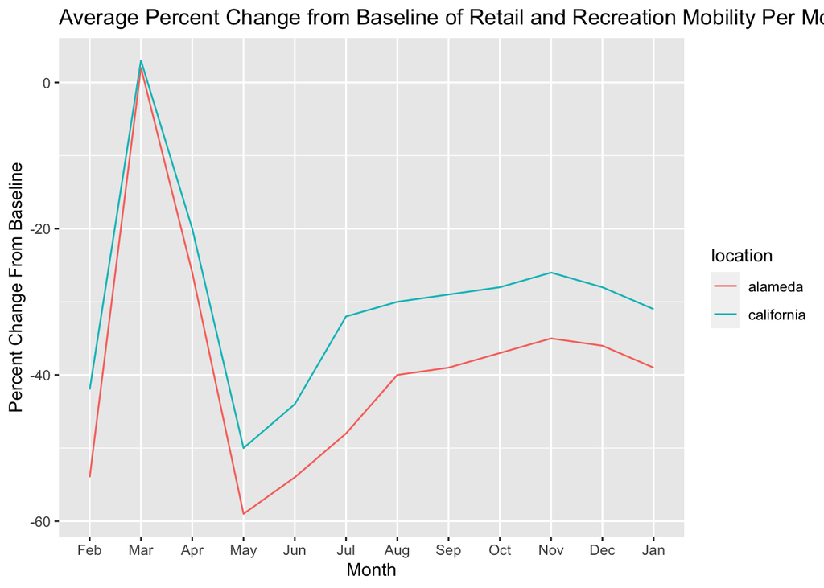

```r
#Graph 2:
al_ca_avg_percent_change_per_month_df$date_numbers <- c(2,3,4,5,6,7,8,9,10,11,12,1)
temp_df <- melt(al_ca_avg_percent_change_per_month_df, id.vars = 'date_numbers', variable.name = 'series') %>%
  filter(series != "year(al_ca_df$formatted_date)") %>%
  filter(series != "month(al_ca_df$formatted_date)") %>%
  filter(series != "change_al") %>%
  filter(series != "change_ca") %>%
  filter(series != "date_names")
temp_df$series <- as.character(temp_df$series)
temp_df$value <- as.integer(temp_df$value)
temp_df$location <- ifelse(grepl("_al", temp_df$series), "alameda", "california")
ggplot(data = temp_df %>% filter(series == "retail_and_recreation_al" | series == "retail_and_recreation_ca"), aes(x = date_numbers, y = value, color = location)) +
  geom_line() +
  xlab("Month") +
  ylab("Percent Change From Baseline") +
  ggtitle("Average Percent Change from Baseline of Retail and Recreation Mobility Per Month in Alameda County, CA and California, 2020-2021") +
  scale_x_discrete(name = "Month",
                   limits = c("Feb", "Mar", "Apr", "May", "Jun", "Jul", "Aug", "Sep",
                              "Oct", "Nov", "Dec", "Jan"))
```

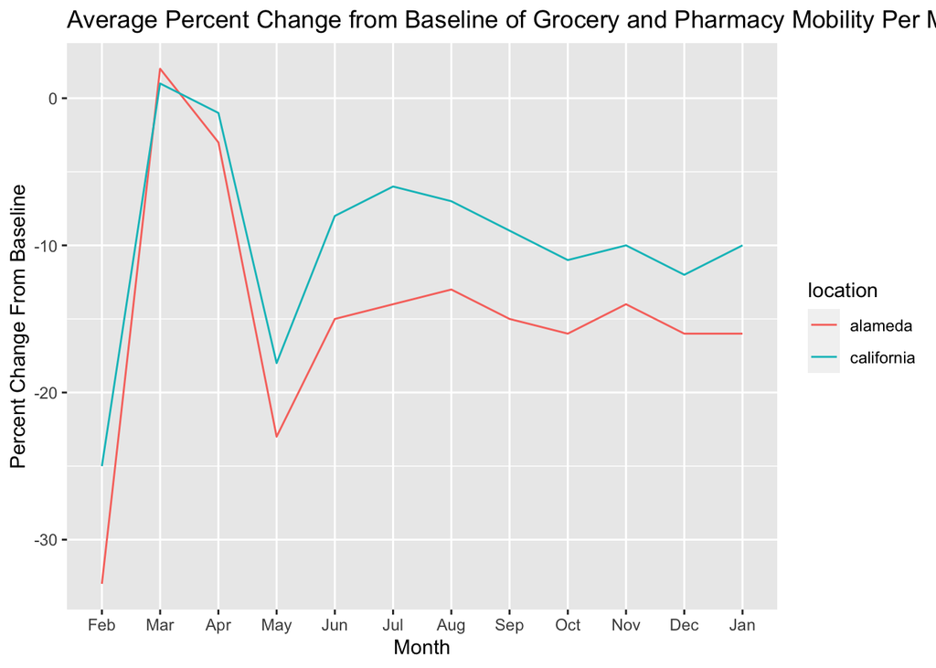

```r
ggplot(data = temp_df %>% filter(series == "grocery_and_pharmacy_al" | series == "grocery_and_pharmacy_ca"), aes(x = date_numbers, y = value, color = location)) +
  geom_line() +
  xlab("Month") +
  ylab("Percent Change From Baseline") +
  ggtitle("Average Percent Change from Baseline of Grocery and Pharmacy Mobility Per Month in Alameda County, CA and California, 2020-2021") +
  scale_x_discrete(name = "Month",
                   limits = c("Feb", "Mar", "Apr", "May", "Jun", "Jul", "Aug", "Sep",
                              "Oct", "Nov", "Dec", "Jan"))
```

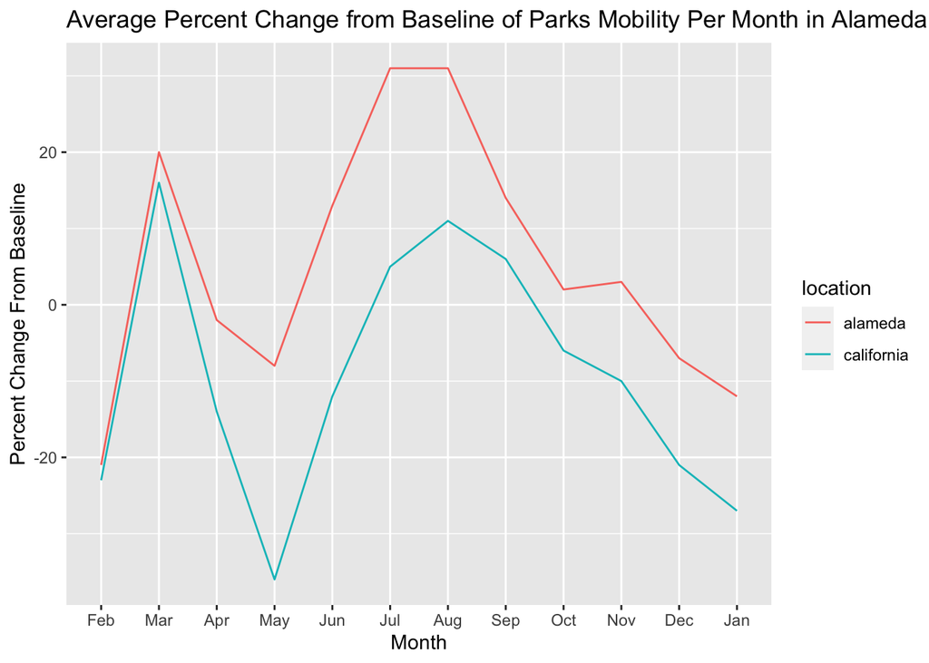

```r
ggplot(data = temp_df %>% filter(series == "parks_al" | series == "parks_ca"), aes(x = date_numbers, y = value, color = location)) +
  geom_line() +
  xlab("Month") +
  ylab("Percent Change From Baseline") +
  ggtitle("Average Percent Change from Baseline of Parks Mobility Per Month in Alameda County, CA and California, 2020-2021") +
  scale_x_discrete(name = "Month",
                   limits = c("Feb", "Mar", "Apr", "May", "Jun", "Jul", "Aug", "Sep",
                              "Oct", "Nov", "Dec", "Jan"))
```

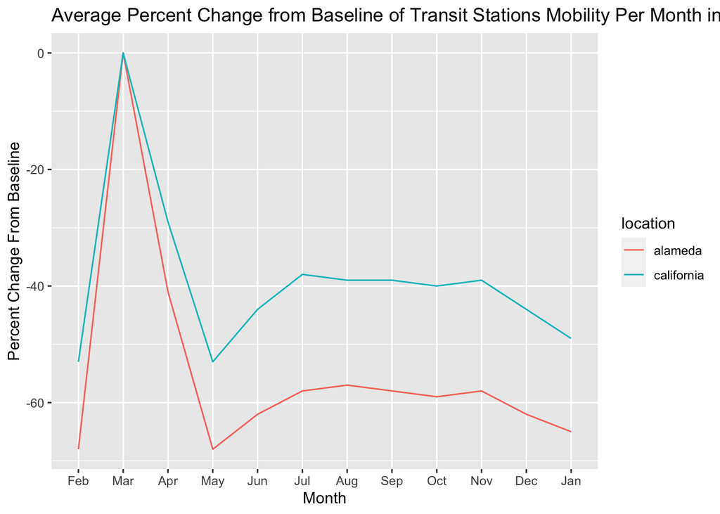

```r
ggplot(data = temp_df %>% filter(series == "transit_station_al" | series == "transit_station_ca"), aes(x = date_numbers, y = value, color = location)) +
  geom_line() +
  xlab("Month") +
  ylab("Percent Change From Baseline") +
  ggtitle("Average Percent Change from Baseline of Transit Stations Mobility Per Month in Alameda County, CA and California, 2020-2021") +
  scale_x_discrete(name = "Month",
                   limits = c("Feb", "Mar", "Apr", "May", "Jun", "Jul", "Aug", "Sep",
                              "Oct", "Nov", "Dec", "Jan"))
```

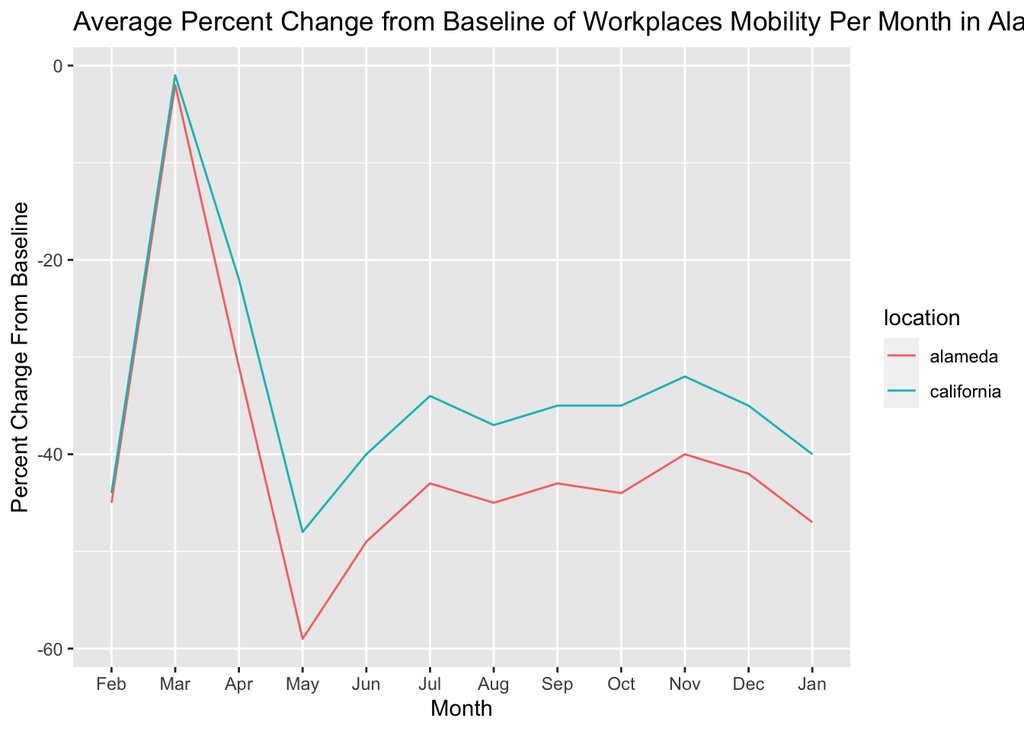

```r
ggplot(data = temp_df %>% filter(series == "workplaces_al" | series == "workplaces_ca"), aes(x = date_numbers, y = value, color = location)) +
  geom_line() +
  xlab("Month") +
  ylab("Percent Change From Baseline") +
  ggtitle("Average Percent Change from Baseline of Workplaces Mobility Per Month in Alameda County, CA and California, 2020-2021") +
  scale_x_discrete(name = "Month",
                   limits = c("Feb", "Mar", "Apr", "May", "Jun", "Jul", "Aug", "Sep",
                              "Oct", "Nov", "Dec", "Jan"))
```

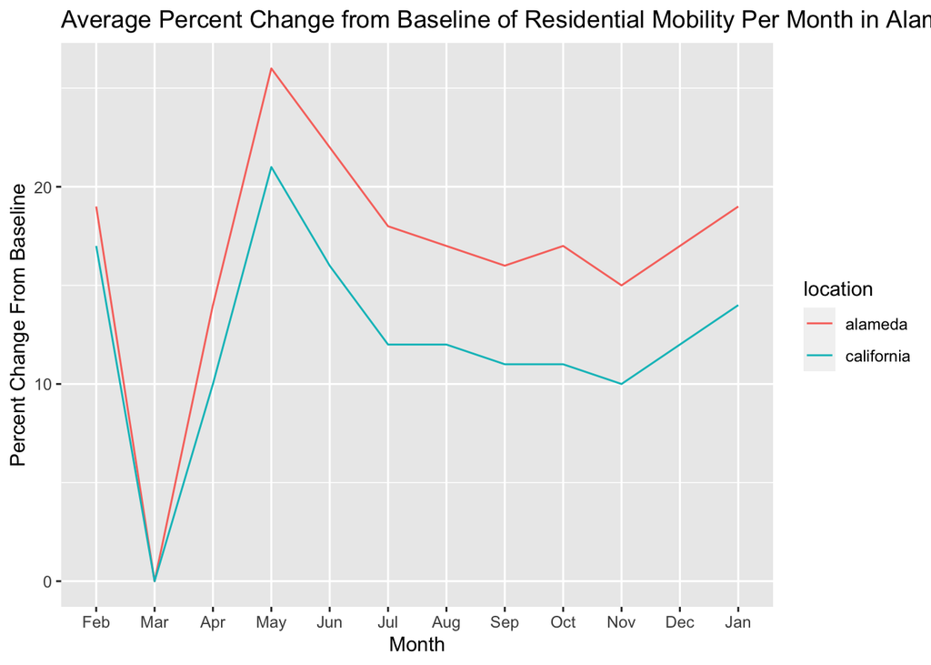

```r
ggplot(data = temp_df %>% filter(series == "residential_al" | series == "residential_ca"), aes(x = date_numbers, y = value, color = location)) +
  geom_line() +
  xlab("Month") +
  ylab("Percent Change From Baseline") +
  ggtitle("Average Percent Change from Baseline of Residential Mobility Per Month in Alameda County, CA and California, 2020-2021") +
  scale_x_discrete(name = "Month",
                   limits = c("Feb", "Mar", "Apr", "May", "Jun", "Jul", "Aug", "Sep",
                              "Oct", "Nov", "Dec", "Jan"))
```

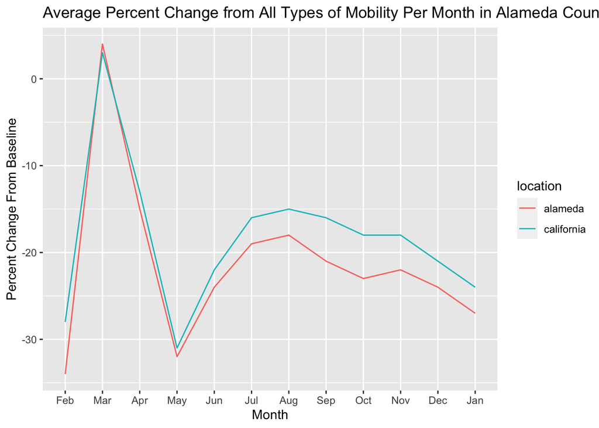

```r
ggplot(data = temp_df %>% filter(series == "all_al" | series == "all_ca"), aes(x = date_numbers, y = value, color = location)) +
  geom_line() +
  xlab("Month") +
  ylab("Percent Change From Baseline") +
  ggtitle("Average Percent Change from All Types of Mobility Per Month in Alameda County, CA and California, 2020-2021") +
  scale_x_discrete(name = "Month",
                   limits = c("Feb", "Mar", "Apr", "May", "Jun", "Jul", "Aug", "Sep",
                              "Oct", "Nov", "Dec", "Jan"))
```

These graphs compare the average percent change in mobility per month for both geographical locations in terms of a range of types of mobility. In order to properly plot the data from the al_ca_avg_percent_change_per_month_df data frame, the same process of manipulating the data and data structures used in the set of graphs comparing the United States and Korea are also used for the set of graphs above.

## Conclusions:

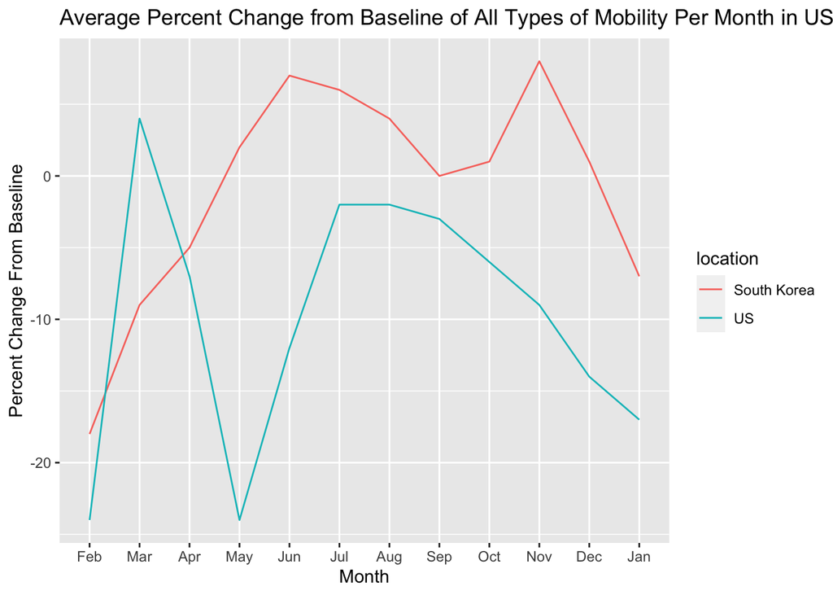

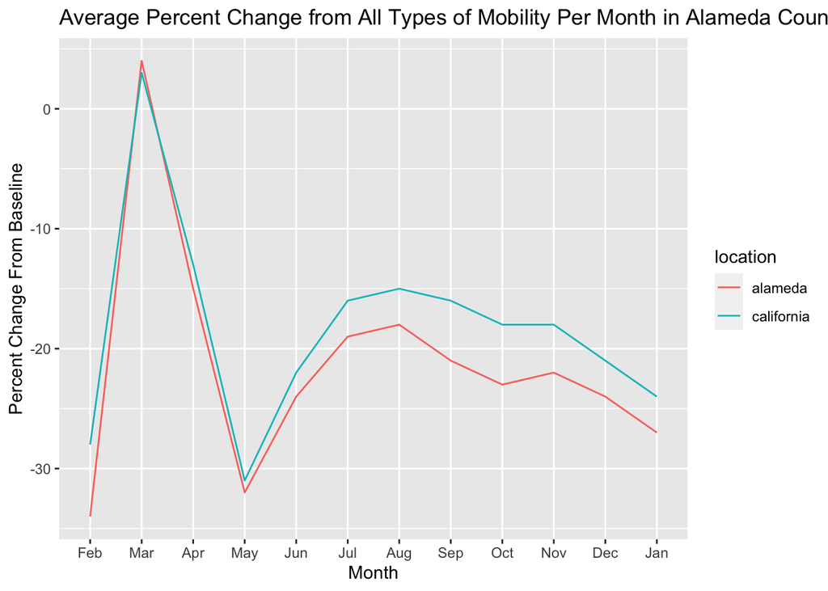